# limma/voom versus edgeR

## Plots and such

First things first, the canonical Venn diagram. (With acknowledgements to the wonderful VennDiagram package notes at http://rstudio-pubs-static.s3.amazonaws.com/13301_6641d73cfac741a59c0a851feb99e98b.html) First we shall compare at an adjusted p-value of 0.05, since that is what many people do (in our experience it usually makes sense to find a combination of fold-change and significance that maximizes the subjective believability of each individual result, but of course any attempt to suggest that priors should exist from the corpus of 300+ years of scientific endeavor tends to face resistance from the hidebound. And there’s always the minor issue of the marginalization paradox for Bayesians…)

```r
library(VennDiagram)
```

```r
getVenn <- function(voom, edgeR) {
  grid.newpage()
  draw.pairwise.venn(area1=length(voom), area2=length(edgeR),
                     cross.area=length(intersect(voom, edgeR)),
                     category=c("limma/voom", "edgeR"), alpha=rep(0.5, 2),
                     fill=c("red", "blue"), lty=rep("blank", 2))
}
```

At p <= 0.1, we get:

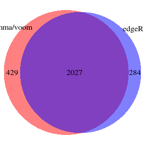

```
## (polygon[GRID.polygon.11], polygon[GRID.polygon.12], polygon[GRID.polygon.13], polygon[GRID.polygon.14], text[GRID.text.15], text[GRID.text.16], text[GRID.text.17], text[GRID.text.18], text[GRID.text.19])
```

```r
getVenn(voom_fdr01, edgeR_fdr01)
```

At p <= 0.05, we get:

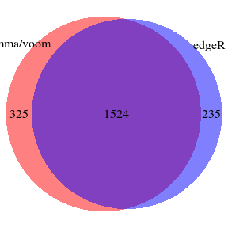

```
## (polygon[GRID.polygon.20], polygon[GRID.polygon.21], polygon[GRID.polygon.22], polygon[GRID.polygon.23], text[GRID.text.24], text[GRID.text.25], text[GRID.text.26], text[GRID.text.27], text[GRID.text.28])
```

```r
getVenn(voom_fdr005, edgeR_fdr005)
```

And at p <= 0.01, we get:

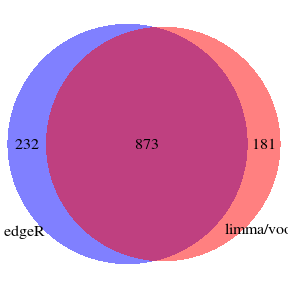

```
## (polygon[GRID.polygon.29], polygon[GRID.polygon.30], polygon[GRID.polygon.31], polygon[GRID.polygon.32], text[GRID.text.33], text[GRID.text.34], text[GRID.text.35], text[GRID.text.36], text[GRID.text.37])
```

```r
getVenn(voom_fdr001, edgeR_fdr001)
```

```r
topVoom <- topTable(voomResults, n=nrow(NS), coef=2)
voomOnly_fdr001 <- setdiff(voom_fdr001, edgeR_fdr001)
topVoom[voomOnly_fdr001, "B"]
```

```
##   [1] 28.9346585943  9.5562583747  8.9785890552  8.7577167297  7.9605408804
##   [6]  7.6368698274  7.6051968701  6.1689005259  5.8743195257  5.5685128006
##  [11]  4.6171397080  4.4882117557  4.2380970204  4.1381457625  3.8020307145
##  [16]  3.7238433509  3.7203379547  3.5782255366  3.5522473395  3.4228047553
##  [21]  3.3144220800  3.2631559356  3.0930880545  3.0628557465  3.0474253288
##  [26]  3.0238705726  3.0084091511  2.9797701196  2.8209768269  2.7770735158
##  [31]  2.7191465002  2.6728132546  2.5013980954  2.3042310257  2.2560613339
##  [36]  2.2448748609  2.2240815284  2.1988345356  2.1770238313  2.1588882810
##  [41]  2.1457799437  2.1135256162  2.0946444037  2.0640086083  2.0291790391
##  [46]  1.9855667480  1.9811201263  1.9758259571  1.9715935926  1.9294071598
##  [51]  1.8349262099  1.8026587195  1.7353995411  1.6867103995  1.5945856765
##  [56]  1.5931406020  1.5890695496  1.5604159358  1.5546106855  1.5455476813
##  [61]  1.4528051256  1.3976422134  1.3940050621  1.3820910425  1.2856501944
##  [66]  1.2814988974  1.2729917705  1.2659937831  1.2635178922  1.2595084805
##  [71]  1.2499707847  1.2445592205  1.1854757805  1.1822862127  1.1667491518
```

[output cut: 22 more lines]

At least the first 9 of these should show up via any reasonable method, IFF they make sense.

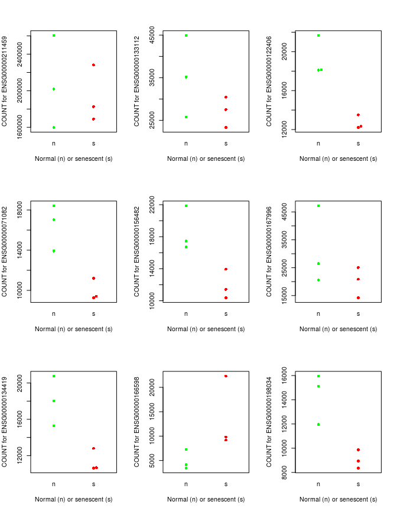

```r
geneTpms <- collapseTpm(NS, bundleID="gene_id")
# geneCounts is already assembled

getBeeswarm <- function(ensg, mat, what=c("tpm", "count", "E-value")) {
  library(beeswarm)
  what <- match.arg(what)
  beeswarm(mat[ensg, ] ~ NS$senescent, col=c("green","red"),
           pch=16, xlab="Normal (n) or senescent (s)",
           ylab=paste(toupper(what), "for", ensg))
}

hugeDiffs <- voomOnly_fdr001[1:9]

# plot 'em: counts
par(mfrow=c(3,3))
for (ensg in hugeDiffs) getBeeswarm(ensg, mat=geneCounts, what="count")
```

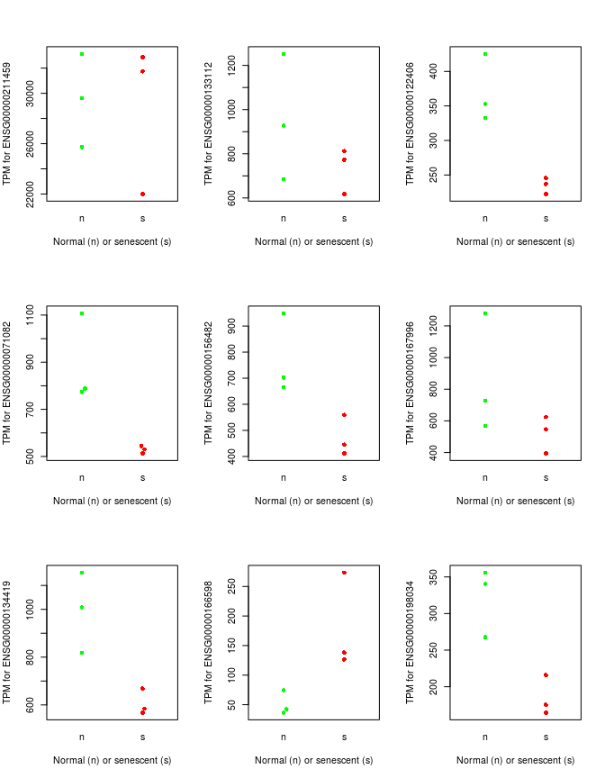

```r
# plot 'em: tpm
par(mfrow=c(3,3))
for (ensg in hugeDiffs) getBeeswarm(ensg, mat=geneTpms)
```

Conversely, what does edgeR favor?

```r
topEdgeR <- topTags(edgeResults, n=nrow(NS))
edgeOnly_fdr001 <- setdiff(edgeR_fdr001, voom_fdr001)
topEdgeR[edgeOnly_fdr001, "LR"]
```

```
## Coefficient:  senescents
##                       LR
## ENSG00000211666 68.84901
## ENSG00000211659 34.74572
## ENSG00000277574 30.39612
## ENSG00000274575 27.45193
## ENSG00000211653 27.45032
## ENSG00000211662 27.26217
## ENSG00000211660 26.69193
## ENSG00000211648 26.68143
## ENSG00000211668 25.82652
## ENSG00000243264 24.90342
## ENSG00000211598 24.03810
## ENSG00000260005 23.41086
## ENSG00000211651 22.75451
## ENSG00000243466 22.43672
## ENSG00000282801 22.43565
## ENSG00000242534 22.06840
## ENSG00000256975 22.06347
## ENSG00000282811 21.69462
## ENSG00000242076 21.69192
## ENSG00000274576 21.57688
## ENSG00000282120 21.06242
## ENSG00000242371 21.06238
## ENSG00000211962 20.95983
## ENSG00000211640 20.30641
## ENSG00000282122 19.37015
## ENSG00000282678 19.36860
## ENSG00000231558 19.07374
## ENSG00000235744 19.07318
## ENSG00000211649 19.07080
## ENSG00000282131 18.70608
## ENSG00000260802 18.65378
## ENSG00000092096 18.55464
## ENSG00000213626 18.44968
## ENSG00000167984 18.32593
## ENSG00000280411 18.30035
## ENSG00000186326 18.29787
## ENSG00000275543 18.29460
## ENSG00000165474 18.19601
```

[output cut: 179 more lines]

```
## ENSG00000124508 13.16228
## ENSG00000228477 13.13753
## ENSG00000118515 13.13659
## ENSG00000231087 13.10355
## ENSG00000170390 13.09664
## ENSG00000173208 13.08816
## ENSG00000114023 13.07708
## ENSG00000211663 13.03213
## ENSG00000138073 13.01725
## ENSG00000136111 13.00348
## ENSG00000258777 13.00142
## ENSG00000167642 12.99905
## ENSG00000013016 12.99834
## ENSG00000180694 12.97812
## ENSG00000188921 12.97617
```

Well, those are some big likelihood ratios. Let’s plot them.

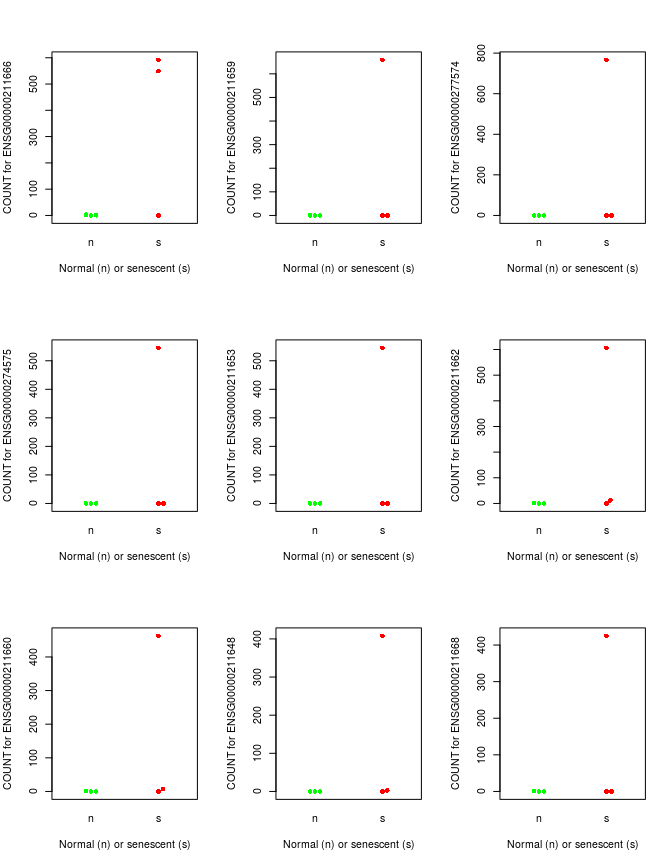

```r
moreHugeDiffs <- edgeOnly_fdr001[1:9]

# plot 'em: counts
par(mfrow=c(3,3))
for (ensg in moreHugeDiffs) getBeeswarm(ensg, mat=geneCounts, what="count")
```

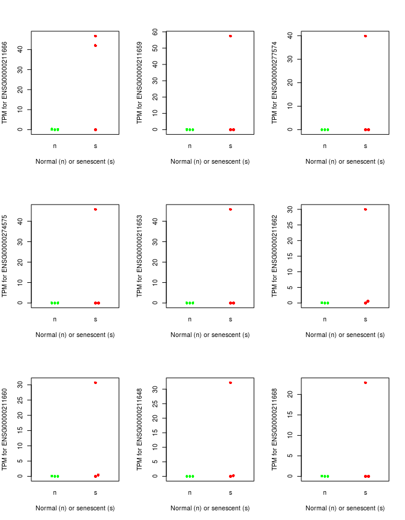

```r
# plot 'em: tpm
par(mfrow=c(3,3))
for (ensg in moreHugeDiffs) getBeeswarm(ensg, mat=geneTpms)
```

At this point it is up to the user or analyst to determine what they’re looking for. I will revisit this topic and look at how these differences influence the interpretation of the results downstream, e.g. for pathway analysis. But it seems pretty clear that each has strengths and weaknesses.

We might want to look at a few of these in Sleuth. Let’s do that:

```r
# see ?withSleuth
library(sleuth)
base_dir <- outputPath # from earlier
sample_id <- samples
kal_dirs <- paste(base_dir, sample_id, sep=.Platform$file.sep)
covs <- data.frame(sample=sample_id,
                   condition=NS$senescent,
                   subject=NS$subject)
df<-data.frame(covs,path=kal_dirs,stringsAsFactors=FALSE)

t2g <- mcols(NS)[, c("tx_id","gene_id","tx_biotype","gene_biotype","gene_name")]
names(t2g) <- c("target_id", "ens_gene", "transcript_biotype",
                "gene_biotype", "ext_gene")
t2g <- as(t2g, "data.frame")
#so <- sleuth_prep(kal_dirs,covs  ~ condition + subject, target_mapping = t2g) outdated...
so <- sleuth_prep(df, ~ condition + subject, target_mapping = t2g)
```

```
## reading in kallisto results
```

```
## ......
```

```
## normalizing est_counts
```

```
## 50400 targets passed the filter
```

```
## normalizing tpm
```

```
## merging in metadata
```

```
## normalizing bootstrap samples
```

```
## summarizing bootstraps
```

```r
so <- sleuth_fit(so)
```

```
## shrinkage estimation
```

```
## computing variance of betas
```

```r
#so <- sleuth_test(so, which_beta = 'conditions')
so<-sleuth_wt(so, 'conditions')
# not run:
# sleuth_live(so)
```

Sleuth Live will only run in a browser, so you’ll have to try it locally.

```
genesToPeruse <- cbind(voomOnly=hugeDiffs, edgeROnly=moreHugeDiffs)
kable(genesToPeruse)
```

```
kable(sleuth_results(so, 'conditions'))
```